说明：这是优达学城数据分析师纳米学位 P0 分析筷子最优长度的项目辅助文件。如果你需要本文件的英文版本，请访问[此链接](https://github.com/udacity/data-analyst/tree/master/projects/chopstick_length)。

# 筷子!

一些研究者打算确定儿童和成人的最佳筷子长度。他们想出了一种用来评定一对筷子的功能有效性的度量，称为“食物夹取性能”。“食物夹取性能”通过对夹取并放在杯子中的花生 (PPPC, peanuts picked and placed in a cup) 计数来确定。

### 确定最佳筷子长度的研究

[摘要和论文链接](http://www.ncbi.nlm.nih.gov/pubmed/15676839)  
*以下摘要改编自链接中的内容*

筷子是人类迄今为止发明的最简单常用的手动工具之一，但尚没有[工效学家](https://www.google.com/search?q=ergonomists)对它做过调查。此调查执行了两项试验室研究，使用[随机完全区组设计](http://dawg.utk.edu/glossary/whatis_rcbd.htm)，来评估筷子长度对成人和儿童食物夹取能力的影响。31 名男性大专生和 21 名小学生作为试验对象，来对 180、210、240、270、300 和 330 毫米的筷子进行测试。结果显示 240 和 180 毫米的筷子分别是成人和儿童的最佳长度。基于这些发现，研究者建议家中有儿童的家庭应同时配备 240 和 180 毫米长的筷子。此外，考虑到工效学和成本之间的权衡，餐厅应提供 210 毫米长的筷子。

### 在此项目的其余部分，仅根据分析 31 名男性大学生的试验回答所有问题

下载[成人数据集](https://www.udacity.com/api/nodes/4576183932/supplemental_media/chopstick-effectivenesscsv/download)（不要想歪），然后根据摘要和数据集回答以下问题。

**如果你双击此单元格**，会看到文本发生变化，所有样式被清除。这将允许你编辑此本文块。此文本块使用 [Markdown](http://daringfireball.net/projects/markdown/syntax) 编写，这是一种使用标题、链接、斜体和许多其他样式选项的文本编辑方式。在纳米学位后面的课程中，你会继续了解如何使用 Markdown。点击 shift + enter 或 shift + return 查看编辑后的文本样式。

#### 1. 此实验中的自变量是什么？

你可双击此单元格在其中添加你的答案，或使用工具栏（在下方插入单元格）中的加号在新的单元格中添加你的答案。 此试验中的自变量是筷子的长度。

#### 2. 此实验中的因变量是什么？

此试验中的因变量是食物夹取性能。

#### 3. 因变量的操作性定义是什么？

因变量的操作性定义是PPPC，即夹取并放在杯子中的花生计数。

#### 4. 基于对实验和数据集的描述，至少列出两个你知道的受控变量。

请主要关注这些参与者之间的共同点。你不必猜测任何变量或阅读整片论文来确定这些变量。（例如，我们可以合理认为筷子的材料是保持不变的，但这在摘要或数据描述中没有说明。因此，筷子材料是受控变量）。 一是试验中分配给每个人的花生是随机的，没有差别的；二是每个人使用筷子的技能没有差别。一是试验中分配给每个人的花生是随机的，没有差别的；二是每个人使用筷子的技能没有差别。三是每个人夹取的时间是一样的。

Ipython notebook 的一个较大的优势是你可以使用代码记录你的数据分析，在代码中添加注释，甚至使用 Markdown 添加文本块。这些 notebook 允许你与他人协作并分享你的工作。现在，我们先来看一些执行统计的代码。

```python
import pandas as pd

# pandas 是一个用来进行数据处理和分析的软件库。
# 我们用一些简短的昵称来称呼库或包。Pandas 的昵称是 pd。
# 点击 shift + enter 来运行这部分的代码。
```

```python
path = r'./chopstick-effectiveness.csv'

# 将地址改为 chopstick-effectiveness.csv 文件所在文件夹。
# 如果运行这段代码出错，请检查上面输入的地址是否正确。

dataFrame = pd.read_csv(path)
dataFrame
```

|  | Food.Pinching.Efficiency | Individual | Chopstick.Length |
| --- | --- | --- | --- |
| 0 | 19.55 | 1 | 180 |
| 1 | 27.24 | 2 | 180 |
| 2 | 28.76 | 3 | 180 |
| 3 | 31.19 | 4 | 180 |
| 4 | 21.91 | 5 | 180 |
| 5 | 27.62 | 6 | 180 |
| 6 | 29.46 | 7 | 180 |
| 7 | 26.35 | 8 | 180 |
| 8 | 26.69 | 9 | 180 |
| 9 | 30.22 | 10 | 180 |
| 10 | 27.81 | 11 | 180 |
| 11 | 23.46 | 12 | 180 |
| 12 | 23.64 | 13 | 180 |
| 13 | 27.85 | 14 | 180 |
| 14 | 20.62 | 15 | 180 |
| 15 | 25.35 | 16 | 180 |
| 16 | 28.00 | 17 | 180 |
| 17 | 23.49 | 18 | 180 |
| 18 | 27.77 | 19 | 180 |
| 19 | 18.48 | 20 | 180 |
| 20 | 23.01 | 21 | 180 |
| 21 | 22.66 | 22 | 180 |
| 22 | 23.24 | 23 | 180 |
| 23 | 22.82 | 24 | 180 |
| 24 | 17.94 | 25 | 180 |
| 25 | 26.67 | 26 | 180 |
| 26 | 28.98 | 27 | 180 |
| 27 | 21.48 | 28 | 180 |
| 28 | 14.47 | 29 | 180 |
| 29 | 28.29 | 30 | 180 |
| ... | ... | ... | ... |
| 156 | 26.18 | 2 | 330 |
| 157 | 25.93 | 3 | 330 |
| 158 | 28.61 | 4 | 330 |
| 159 | 20.54 | 5 | 330 |
| 160 | 26.44 | 6 | 330 |
| 161 | 29.36 | 7 | 330 |
| 162 | 19.77 | 8 | 330 |
| 163 | 31.69 | 9 | 330 |
| 164 | 24.64 | 10 | 330 |
| 165 | 22.09 | 11 | 330 |
| 166 | 23.42 | 12 | 330 |
| 167 | 28.63 | 13 | 330 |
| 168 | 26.30 | 14 | 330 |
| 169 | 22.89 | 15 | 330 |
| 170 | 22.68 | 16 | 330 |
| 171 | 30.92 | 17 | 330 |
| 172 | 20.74 | 18 | 330 |
| 173 | 27.24 | 19 | 330 |
| 174 | 17.12 | 20 | 330 |
| 175 | 23.63 | 21 | 330 |
| 176 | 20.91 | 22 | 330 |
| 177 | 23.49 | 23 | 330 |
| 178 | 24.86 | 24 | 330 |
| 179 | 16.28 | 25 | 330 |
| 180 | 21.52 | 26 | 330 |
| 181 | 27.22 | 27 | 330 |
| 182 | 17.41 | 28 | 330 |
| 183 | 16.42 | 29 | 330 |
| 184 | 28.22 | 30 | 330 |
| 185 | 27.52 | 31 | 330 |

186 rows × 3 columns

现在我们使用代码来对数据进行一项基本的统计计算！运行下面的代码块来计算全部 31 名参与者和所有筷子长度的平均“食物夹取效率”。

```python
dataFrame['Food.Pinching.Efficiency'].mean()
```

```
25.00559139784947
```

这个数据是有用的，但是它无法让我们知道对于这 31 名男性大学生，哪个筷子长度性能最佳。下一个代码块将生成每个筷子长度的平均“食物夹取效率”。运行下面的代码块。

```python
meansByChopstickLength = dataFrame.groupby('Chopstick.Length')['Food.Pinching.Efficiency'].mean().reset_index()
meansByChopstickLength

# reset_index() 将 Chopstick.Length 从索引（index）改为列（column）。
# 这样筷子的长度就不是索引，现在索引已经成为行数 0, 1, 2, 3, 4, 5。
```

|  | Chopstick.Length | Food.Pinching.Efficiency |
| --- | --- | --- |
| 0 | 180 | 24.935161 |
| 1 | 210 | 25.483871 |
| 2 | 240 | 26.322903 |
| 3 | 270 | 24.323871 |
| 4 | 300 | 24.968065 |
| 5 | 330 | 23.999677 |

#### 5. 对于 31 名男性大学生来说，哪个筷子长度性能最好？

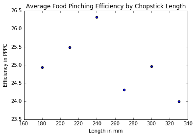

```python
# 让绘图在 Notebook 中显示，而不是在新建窗口中显示。

%pylab inline

import matplotlib.pyplot as plt

plt.scatter(x=meansByChopstickLength['Chopstick.Length'], y=meansByChopstickLength['Food.Pinching.Efficiency'])
            # title="")
plt.xlabel("Length in mm")
plt.ylabel("Efficiency in PPPC")
plt.title("Average Food Pinching Efficiency by Chopstick Length")
plt.show()
```

#### 6. 根据上述代码创建的散点图，解释你观察到的关系。你注意到哪些信息？

从上图的散点图可以看出，筷子长度为240mm的时候，食物夹取性能最高，长度减小或增加之后食物夹取性能都变低了。另外，随着筷子长度的继续增长，食物夹取性能并不是一直降低的，从270mm左右到300mm左右反而石增高的。

### 在摘要中，研究者表示他们的结果显示食物夹取性能受筷子长度影响较大，大约 240 毫米长的筷子是成人的最佳长度

#### 7a. 根据你分析的数据，你是否同意此说法？

不同意此说法。

#### 7b. 为什么？

因为研究者只选取了31名成年男性来代表所有成人，并没有选取女性，这样得出的结果是有偏的，而且只选取了31名男性大专生，并不是从成人的范围中随机选取。